# Assignment 2

## Submit as an HTML file

Print your name below

```python
# Write your answer
print("Jack Chapon")
```

```
Jack Chapon
```

(a) Import the pandas and matplotlib packages

```python
# Write your answer
import matplotlib.pyplot as plt
import pandas as pd
```

(b) Open the dataset "united_states_co2_emissions.csv" in the "data" folder

- Read it as a pandas object called "us_emissions"
- Note: This contains CO2 emissions (in kilotons) by the United States from 1960-2019.

It is compiled from various sources, including the United Nations Framework Convention  
on Climate Change (UNFCCC) and the International Energy Agency (IEA).

```python
# Write your answer
us_emissions = pd.read_csv('data/united_states_co2_emissions.csv')
us_emissions
```

|  | year | total_emissions |
| --- | --- | --- |
| 0 | 1960 | 2.890696e+06 |
| 1 | 1961 | 2.880506e+06 |
| 2 | 1962 | 2.987208e+06 |
| 3 | 1963 | 3.119231e+06 |
| 4 | 1964 | 3.255995e+06 |
| 5 | 1965 | 3.390923e+06 |
| 6 | 1966 | 3.561878e+06 |
| 7 | 1967 | 3.695709e+06 |
| 8 | 1968 | 3.831355e+06 |
| 9 | 1969 | 4.024749e+06 |
| 10 | 1970 | 4.328905e+06 |
| 11 | 1971 | 4.356770e+06 |
| 12 | 1972 | 4.564953e+06 |
| 13 | 1973 | 4.770195e+06 |
| 14 | 1974 | 4.598488e+06 |
| 15 | 1975 | 4.406330e+06 |
| 16 | 1976 | 4.613101e+06 |
| 17 | 1977 | 4.742293e+06 |
| 18 | 1978 | 4.890861e+06 |
| 19 | 1979 | 4.901796e+06 |
| 20 | 1980 | 4.723210e+06 |
| 21 | 1981 | 4.535800e+06 |
| 22 | 1982 | 4.306748e+06 |
| 23 | 1983 | 4.341878e+06 |
| 24 | 1984 | 4.475192e+06 |
| 25 | 1985 | 4.492555e+06 |
| 26 | 1986 | 4.495463e+06 |
| 27 | 1987 | 4.688373e+06 |
| 28 | 1988 | 4.892526e+06 |
| 29 | 1989 | 4.955081e+06 |
| 30 | 1990 | 4.844520e+06 |
| 31 | 1991 | 4.807500e+06 |
| 32 | 1992 | 4.879630e+06 |
| 33 | 1993 | 4.995210e+06 |
| 34 | 1994 | 5.066810e+06 |
| 35 | 1995 | 5.117040e+06 |
| 36 | 1996 | 5.273490e+06 |
| 37 | 1997 | 5.543350e+06 |
| 38 | 1998 | 5.590540e+06 |
| 39 | 1999 | 5.609020e+06 |
| 40 | 2000 | 5.775810e+06 |
| 41 | 2001 | 5.748260e+06 |
| 42 | 2002 | 5.593030e+06 |
| 43 | 2003 | 5.658990e+06 |
| 44 | 2004 | 5.738290e+06 |
| 45 | 2005 | 5.753490e+06 |
| 46 | 2006 | 5.653080e+06 |
| 47 | 2007 | 5.736320e+06 |
| 48 | 2008 | 5.558380e+06 |
| 49 | 2009 | 5.156430e+06 |
| 50 | 2010 | 5.392110e+06 |
| 51 | 2011 | 5.173600e+06 |
| 52 | 2012 | 4.956060e+06 |
| 53 | 2013 | 5.092100e+06 |
| 54 | 2014 | 5.107210e+06 |
| 55 | 2015 | 4.990710e+06 |
| 56 | 2016 | 4.894500e+06 |
| 57 | 2017 | 4.819370e+06 |
| 58 | 2018 | 4.975310e+06 |
| 59 | 2019 | 4.817720e+06 |

(c) View the dataset and create a list of variable names

- Create a list, e.g. "variable_names = [ "name1", "name2"]"
- Manually type the names of the 2 variables

```python
# Write your answer
print(us_emissions)

us_emissions_list = ["year", "total_emissions"]
us_emissions_list
```

```
    year  total_emissions
0   1960     2.890696e+06
1   1961     2.880506e+06
2   1962     2.987208e+06
3   1963     3.119231e+06
4   1964     3.255995e+06
5   1965     3.390923e+06
6   1966     3.561878e+06
7   1967     3.695709e+06
8   1968     3.831355e+06
9   1969     4.024749e+06
10  1970     4.328905e+06
11  1971     4.356770e+06
12  1972     4.564953e+06
13  1973     4.770195e+06
```

[output cut: 46 more lines]

```
['year', 'total_emissions']
```

(d) Compute descriptive statistics for the 2nd variable in the dataset

- One way to do this is:

us_emissions["total_emissions"].describe()

- Do something similar, but with the list you created above.
- Substitute "total_emissions" with a command that automatically extracts the 2nd element in the list
- Remember that the numbering in Python starts at zero
- For example:

list_colors = ["red","green","yellow"]

list_colors[2] will output "yellow"

```python
# Write your answer
print(us_emissions[us_emissions_list[1]].describe())
```

```
count    6.000000e+01
mean     4.733944e+06
std      7.568200e+05
min      2.880506e+06
25%      4.457976e+06
50%      4.862075e+06
75%      5.160723e+06
max      5.775810e+06
Name: total_emissions, dtype: float64
```

(e) Import the datasets as you did in part (b) for any 2 countries from the  
"data" folder and create 2 scatter plots that have "year" in the x-axis and  
"total_emissions" in the y-axis.

- The "data" folder contains the datasets for the top 10 CO2 emitting countries
- Label the axes for full points
- Use "plt.title("Relevant Title for Plot")" to label the title
- Use "plt.show()" after creating each plot to ensure both are displayed
- Note: This question does not depend on (d)

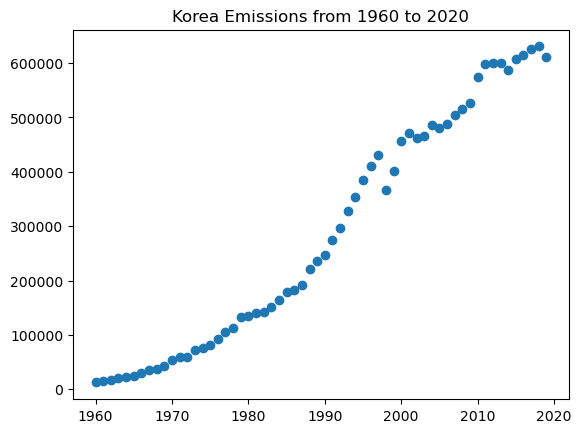

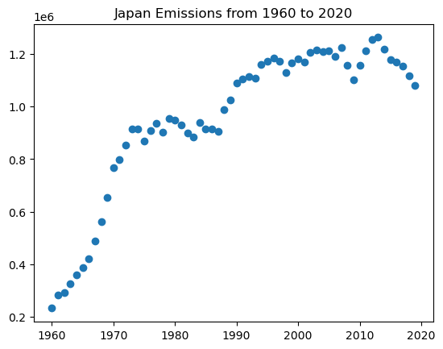

```python
# Write your answer
korea_emissions = pd.read_csv('data/korea_rep_co2_emissions.csv')
japan_emissions = pd.read_csv('data/japan_co2_emissions.csv')

plt.scatter(x= korea_emissions["year"], y= korea_emissions["total_emissions"])
plt.title("Korea Emissions from 1960 to 2020")
plt.show()


plt.scatter(x= japan_emissions["year"], y= japan_emissions["total_emissions"])
plt.title("Japan Emissions from 1960 to 2020")
plt.show()
```